# Part II - (Explanatory Visualization on Loan Data from Prosper)

## by (Jedidah Kariuki)

## Investigation Overview

From the summary findings, the observations made were

- Most of the relationships between the numeric variables of the dataset containing the features of interest are weakly correlated either negatively or positively. For example, the relationship between loan amount and the other features show a significantly weak negative or positive correlation except the MonthlyLoanPayment at 0.932. This indicates that the higher the loan amount, the more the monthly loan payment which is logical.
- There is a linear relationship between applicable loan amount and number of investors funding the loan. But this can be affected by the theory of a few investors funding with more money or vice versa.
- The prosper rating also has an effect on the number of investors considering the rating allows potential investors to consider all possible levels of risk in a loan application.
- Status of employment is a factor in the amount of loan a borrower is given which subsequently affects the number of investors funding the applicable loans.

In the next steps, I'll polish a few plots from the exploration section into an understandable format.

## Dataset Overview

The dataset to be used here is a sample dataset of the original one. The sample dataset contains main features of interest (17 to be precise) used to perform exploration of the dataset.

#### Correlation Plots of the Numeric Variables

The first plot to polish depicts the base relationship between the original loan amount and the other numerical variables in the sample dataset.

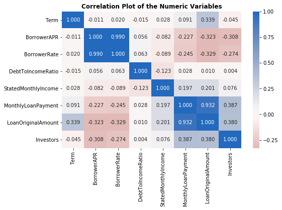

```python
# correlation plot of the numeric variables
plt.figure(figsize = [8, 5])
sb.heatmap(new_loan_df[numeric_vars].corr(), annot = True, fmt = '.3f',
           cmap = 'vlag_r', center = 0)
plt.title('Correlation Plot of the Numeric Variables', fontweight='bold')
plt.show()
```

### Bivariate Plots

Let's specifically polish the bivariate relationship between loan amount and that depict relationships between loan amount and the features of interest.

#### Distribution of Original Loan Amount and Monthly Payment

A notable logical correlation between loan amount and monthly loan payment. A positive association exists between the two features.

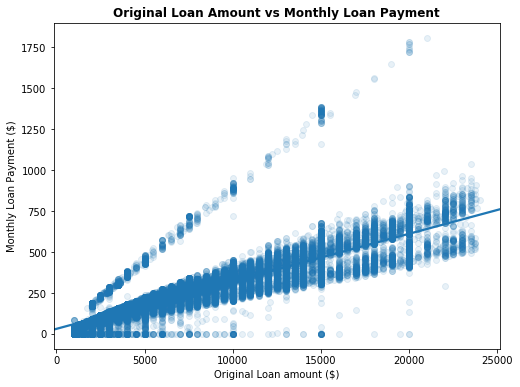

```python
#Distribution of loan amount against monthly payment
plt.figure(figsize = [8, 6])

sb.regplot(data = new_loan_df, x = 'LoanOriginalAmount', y = 'MonthlyLoanPayment', scatter_kws={'alpha':0.1})
plt.xlabel('Original Loan amount ($)')
plt.ylabel('Monthly Loan Payment ($)')
plt.title('Original Loan Amount vs Monthly Loan Payment', fontweight='bold');
```

#### Distribution of Original Loan Amount and Prosper Rating

Borrowers with higher prosper rating have higher loan amount.

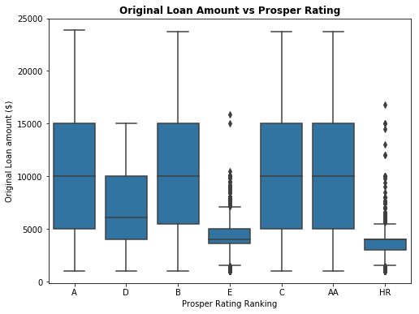

```python
#Distribution of loan amount compared to prosper rating
plt.figure(figsize = [8, 6])
base_color = sb.color_palette()[0]

sb.boxplot(data=new_loan_df, x = 'ProsperRating (Alpha)', y = 'LoanOriginalAmount', color=base_color);
plt.ylabel('Original Loan amount ($)')
plt.xlabel('Prosper Rating Ranking')
plt.title('Original Loan Amount vs Prosper Rating', fontweight='bold');
```

#### Distribution of Original Loan Amount and Length of the loan

The starting amount for a long term loan is higher compared to the other two terms.

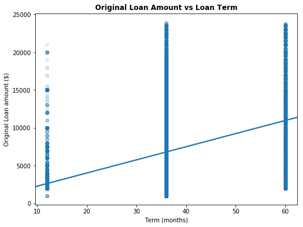

```python
#Distribution of loan amount compared to Term

plt.figure(figsize = [8, 6])

sb.regplot(data = new_loan_df, y = 'LoanOriginalAmount', x = 'Term', scatter_kws={'alpha':0.1})
plt.ylabel('Original Loan amount ($)')
plt.xlabel('Term (months)')
plt.title('Original Loan Amount vs Loan Term', fontweight='bold');
```

#### Distribution of Original Loan Amount and Status of Employment

Status of employment does play a role in the applicable loan amount. This is probably due to the level of risks involved in the loan application. Having a job increases a borrower's success in getting the loan.

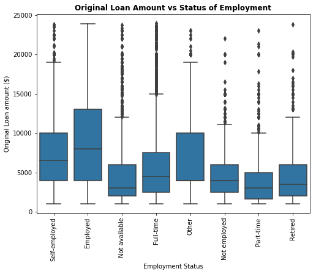

```python
#Distribution of loan amount compared to employment status
plt.figure(figsize = [8, 6])
base_color = sb.color_palette()[0]

sb.boxplot(data=new_loan_df, x = 'EmploymentStatus', y = 'LoanOriginalAmount', color=base_color);
plt.ylabel('Original Loan amount ($)')
plt.xlabel('Employment Status')
plt.title('Original Loan Amount vs Status of Employment', fontweight='bold');
plt.xticks(rotation = 90);
```

### Multivariate Plots

In the next steps, we polish multivariate plots of loan amount against term, prosper rating and employment status in relation to the investors funding the loan and laid out loan payment.

#### Distribution of the Term effect on the Original Loan Amount and Monthly Loan Payment

The original loan amount and the monthly loan payment have a good linear relationship for each term. With a longer term, the monthly loan payment decreases for a high loan amount.

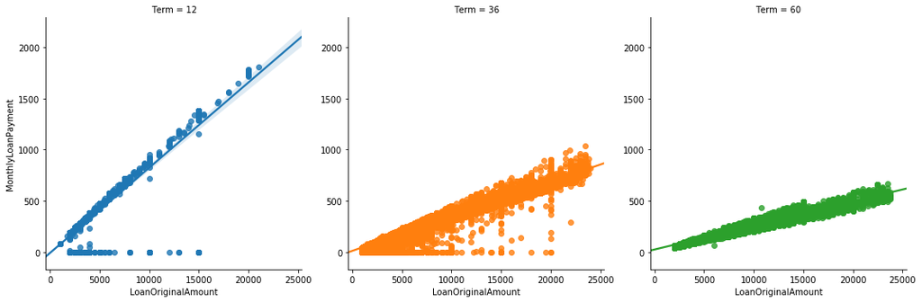

```python
#Term effect on the loan amount and Monthly payment

# g=sb.FacetGrid(data=new_loan_df, aspect=1.2, size=4, col='Term', col_wrap=3)
# g.map(sb.regplot, 'LoanOriginalAmount', 'MonthlyLoanPayment', x_jitter=0.04, scatter_kws={'alpha':0.1})
# g.add_legend();
sb.lmplot(x = 'LoanOriginalAmount', y = 'MonthlyLoanPayment', data = new_loan_df, hue = 'Term', col = 'Term');
```

#### Distribution of the Term effect on the Original Loan Amount and Investors

There is a linear relationship between loan amount and investors for each term. However, short term attracts more investors to fund the loan as compared to a longer term.

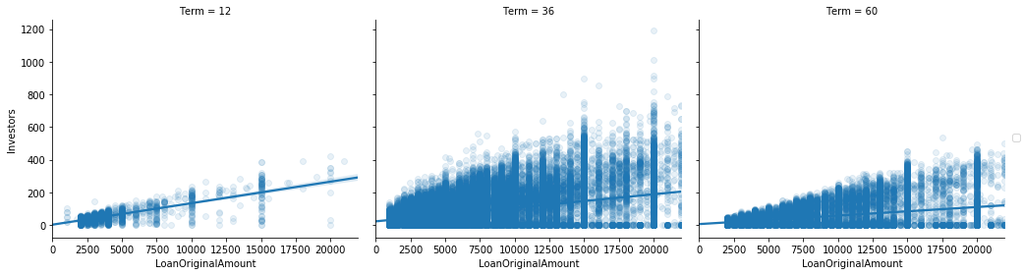

```python
#Term effect on the loan amount and Investors

g=sb.FacetGrid(data=new_loan_df, aspect=1.2, size=4, col='Term', col_wrap=3);
g.map(sb.regplot, 'LoanOriginalAmount', 'Investors', x_jitter=0.04, scatter_kws={'alpha':0.1});
g.add_legend();
```

#### Distribution of the Status of Employment effect on the Original Loan Amount and Investors

Most employed borrowers receive more loan money and subsequently the number of investors funding the loan also increases. This is probably due to consistency of monthly loan payment that comes with employment.

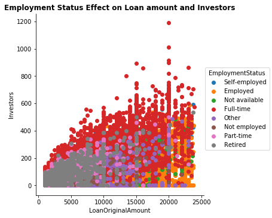

```python
#Employment status effect on the loan amount and Investors

g = sb.FacetGrid(data = new_loan_df, hue = 'EmploymentStatus', size = 5);
g.map(plt.scatter, 'LoanOriginalAmount', 'Investors');
plt.title('Employment Status Effect on Loan amount and Investors', fontweight ='bold');
g.add_legend();
```

#### Distribution of the Term effect on the Prosper Rating and Investors

A high prosper rating attracts more investors whose number increases with the length of the term. For low ratings, a borrower with a long term to pay the loan attracts less investors.

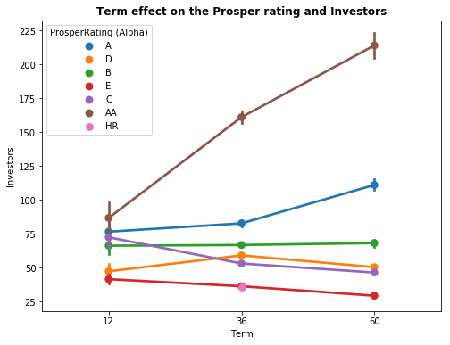

```python
#Term effect on the Prosper rating and Investors
plt.figure(figsize = [8,6])

sb.pointplot(data = new_loan_df, x = 'Term', y = 'Investors', hue = 'ProsperRating (Alpha)');
plt.title('Term effect on the Prosper rating and Investors', fontweight='bold');
```

#### Distribution of the Prosper Rating effect on Original Loan Amount and Investors

Prosper rating has a linear effect on the relationship beteen loan amount and investors.

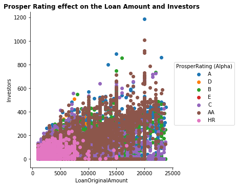

```python
#Prosper rating effect on loan amount and Investors

g = sb.FacetGrid(data = new_loan_df, hue = 'ProsperRating (Alpha)', size = 5);
g.map(plt.scatter, 'LoanOriginalAmount', 'Investors');
plt.title('Prosper Rating effect on the Loan Amount and Investors', fontweight='bold');
g.add_legend();
```

### Conclusion

Term, Prosper rating and employment status are important factors when considering a borrower's loan application which subsequently affects the number of investors funding the loan and the monthly loan payment to be scheduled.